# **Maternity and paternity leave in the United States:** *A series of visualizations.*

By: Angelica Valdiviezo I.

## Setup

### Theme

```
ThemeRegistry.enable('my-chart')
```

## Visualizations

### **Paid maternity and parental leave: a comparison of OECD countries through time**

[interactive chart not shown]

###### Source: "OECD Gender Data Portal Employment Data". Available in OECD.Stat (https://stats.oecd.org/index.aspx?queryid=54760).

*Note:* Total duration of paid maternity and parental leave refers to the total number of weeks which a women can be on paid leave after the birth of a child combining both maternity and parental leave.

The United States, the biggest economy of the world, does not offer fair time for its workers to welcome a new family member. In comparison, some of the most developed countries in the world over 160 paid weeks. Several of the other developed countries have increased their paid leave in the last three decades. A majority of the OECD countries have increased the paid leave in the last three decades. Even some countries who have not increased the paid leave at least guarantee some paid leave, such as Mexico, who offers 12 weeks.

### **Paid maternity and father-specific leave**

[interactive chart not shown]

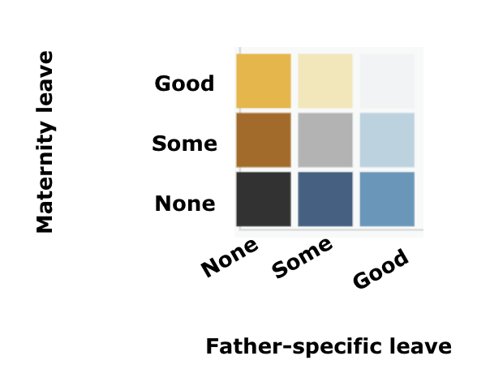

###### Source: "OECD Gender Data Portal Employment Data". Available in OECD.Stat (https://stats.oecd.org/index.aspx?queryid=54760).

Notes:

- *Maternity leave refers to the number of weeks of job-protected leave available for mothers just before and after childbirth.*
- *Paid father-specific leave refers to the number of paid weeks reserved for the exclusive use of fathers.*
- *For maternity leave:*
> - **None** refers to zero weeks
> - **Some** refers to less than 14 weeks (the minimum recommended by the World Health Organization).
> - **Good** refers to 14 or more weeks.
- *For paternity leave:*
> - **None** refers to zero weeks
> - **Some** refers to less than 8 weeks.
> - **Good** refers to 8 or more weeks.

Within the OCDE countries, a regional variation is appreciated.

In the Americas, only Mexico has some maternity and father-specific leave. Though Canada has is well-off for maternity leave, it lacks father-specific leave (as of 2016). As previously mentioned, the United States stands out as the country with no leave for mothers nor fathers.

In contrast, the European regions displays a different story. As most countries have lighter shades of yellow and blue, we note the region has some or good father-specific and maternity leave. The trend behaves quite simarly for the two Asian OECD economies -Korea and Japan-, as well as for Australia and New Zeland.

### **Regional progress in maternity leave regulation from 1990 - 2016**

[interactive chart not shown]

###### Source: "OECD Gender Data Portal Employment Data". Available in OECD.Stat (https://stats.oecd.org/index.aspx?queryid=54760).

Note: *Maternity leave refers to the number of weeks of job-protected leave available for mothers just before and after childbirth.*

As previously seen, the US saw no changes in maternity leave regulation in over two decades, from 1990 to 2016. This trend is the same for all the rest of the Americas, as well as a large share of Europe. Key outliers include countries in the north of Europe, where Ireland leads with an increase of over 24 weeks. Some emodest increase is observed in Australia and New Zeland, as well as the only OECD Asian countries (Korea and Japan).

### **Access to paid and unpaid leave in the US**

[interactive chart not shown]

Source: "American Time Use Survey (ATUS) 2017-18 Leave and Job Flexibilities Module. Available at: https://www.bls.gov/tus/datafiles-2018.htm

Note: *All bars sum to around 100%, equal to the total US population.*

The US has no legislation for paid leave at the federal level; despite this lack of legislation, over 80% of Americans have access to both paid and unpaid leave for the birth or adoption of a child. However, in reality, an alarming 4% report not having access to any kind of leave. Similarly alarming, over 12% of americans only have access to unpaid leave.

Surprinsigly, male and female workers have similar rates of access to paid and unpaid leave in the US.

### **Access to paid and unpaid leave in the US, by gender**

[interactive chart not shown]

Source: "American Time Use Survey (ATUS) 2017-18 Leave and Job Flexibilities Module. Available at: https://www.bls.gov/tus/datafiles-2018.htm

Note: *Each bar sums to 100%, equal to the total US population for that given gender.*

Men and women have very similar distributions of access to leave by payment type. Men and women have almost the exact same percent of access (~95%) to any type of leave, paid or not. However, they experience a difference between access to unpaid, since a greater proportion of men (13%) have access, compared to women (11%). This is the only perceptible different, and even then, the magnitude of this difference is negligible.

### **Support for women after birth**

[figure not shown]

Source: Harris Interactive, Inc., 2013, "Harris 2013 Listening to Mothers III, study no. 42389/42390", https://doi.org/10.15139/S3/11925, UNC Dataverse, V2.

*Notes:*

- Each bar sums to 100%, equal to the total US population of mothers, ages 18-45, for a given race.
- Support refers to:
  - Emotional support, such as listening to concerns and giving good advice.
  - Practical, such as helping get things done or give needed information.
  - Affectionate, such as showing womeen affection and helping them feel wanted.
  - Enjoyment, such as having fun or relaxing together.

As previously seen, men and women have similar rates of access to maternity/father-specific leave. However, it might concern us how this translate to birthing mothers' feelings of support by their partners.

### **Employment and partner status**

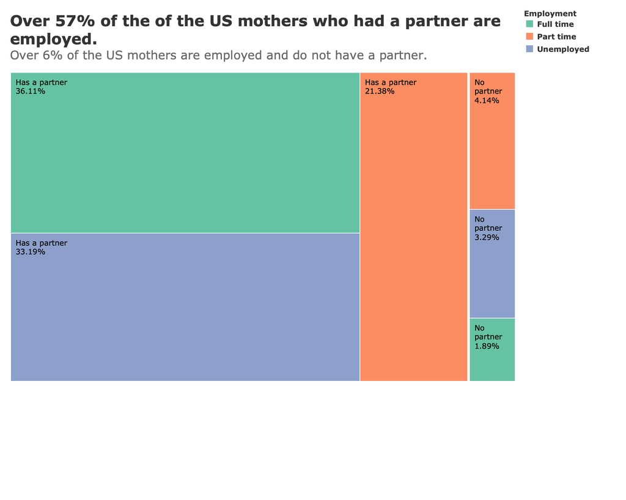

Source: Harris Interactive, Inc., 2013, "Harris 2013 Listening to Mothers III, study no. 42389/42390", https://doi.org/10.15139/S3/11925, UNC Dataverse, V2.

It is concerning that only 8 out of 10 women in the US have access to paid maternity leave, as not all employed women have a partner who they might share the responsibilities with. To be exact, over 6% of mothers who are employed do not have a partner. Moreover, more than 3% of the US mothers are not employed and do not have a partner. This amounts to almost 10% of mothers in the US who are facing very challenging situations around care for a baby and their own recovery from birth.

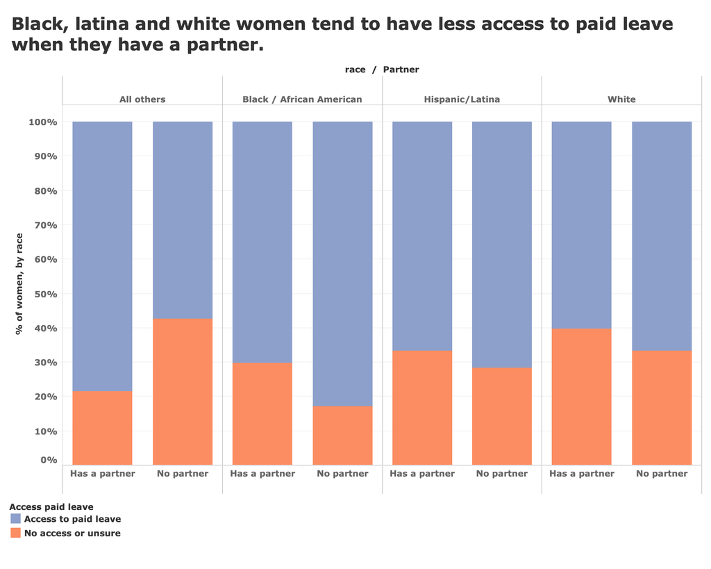

Source: Harris Interactive, Inc., 2013, "Harris 2013 Listening to Mothers III, study no. 42389/42390", https://doi.org/10.15139/S3/11925, UNC Dataverse, V2.

A very relevant intersection is that between race, partner status and access to paid leave. Surprisingly, mother tend to have less access to paid leave if they have a partner. This result is consistent for black, hispanic and white women. This curious finding may be speaking about the dynamics for mothers. A hypothesis could be that women might be willing to accept no paid leave if they have a partner, as the loss in income can be supported by the partner.